# Arcas-HLA Typing Report

# Allele frequency summary

```r
hla_long <- hla_df %>%
  pivot_longer(
    cols = c(Allele1, Allele2),
    names_to = "Allele_Copy",
    values_to = "Allele"
  ) %>%
  filter(!is.na(Allele), Allele != "")

allele_counts <- hla_long %>%
  count(Gene, Allele, sort = TRUE)

write_csv(allele_counts, file.path(out_dir, "arcasHLA_allele_counts.csv"))

allele_counts %>%
  kable() %>%
  kable_styling(full_width = FALSE)
```

| Gene | Allele | n |
| --- | --- | --- |
| DQA1 | DQA1*03:01:01 | 5 |
| DQB1 | DQB1*03:02:01 | 5 |
| C | C*04:01:01 | 4 |
| DQB1 | DQB1*03:01:01 | 4 |
| A | A*11:01:01 | 3 |
| A | A*24:02:01 | 3 |
| DQA1 | DQA1*04:01:01 | 3 |
| DQA1 | DQA1*05:05:01 | 3 |
| DQB1 | DQB1*04:02:01 | 3 |
| DRB1 | DRB1*04:07:01 | 3 |
| DRB1 | DRB1*11:04:01 | 3 |
| A | A*02:01:01 | 2 |
| A | A*31:01:02 | 2 |
| B | B*35:12:01 | 2 |
| B | B*39:08 | 2 |
| C | C*01:02:01 | 2 |
| C | C*07:01:01 | 2 |
| C | C*07:02:01 | 2 |
| DRB1 | DRB1*08:02:01 | 2 |
| A | A*01:01:01 | 1 |
| A | A*02:844 | 1 |
| A | A*26:01:01 | 1 |
| A | A*68:01:02 | 1 |
| B | B*07:05:01 | 1 |
| B | B*08:01:01 | 1 |
| B | B*15:01:01 | 1 |
| B | B*18:01:01 | 1 |
| B | B*35:01:01 | 1 |
| B | B*35:02:01 | 1 |
| B | B*35:43:01 | 1 |
| B | B*38:01:01 | 1 |
| B | B*40:02:01 | 1 |
| B | B*52:01:01 | 1 |
| C | C*03:05:01 | 1 |
| C | C*12:02:02 | 1 |
| C | C*12:03:01 | 1 |
| C | C*15:05:02 | 1 |
| DQA1 | DQA1*01:02:01 | 1 |
| DQA1 | DQA1*03:03:01 | 1 |
| DQA1 | DQA1*05:03:01 | 1 |
| DQB1 | DQB1*04:02:05 | 1 |
| DQB1 | DQB1*05:01:01 | 1 |
| DRB1 | DRB1*04:01:01 | 1 |
| DRB1 | DRB1*04:02:01 | 1 |
| DRB1 | DRB1*04:11:01 | 1 |
| DRB1 | DRB1*08:01:01 | 1 |
| DRB1 | DRB1*14:02:01 | 1 |
| DRB1 | DRB1*15:01:01 | 1 |

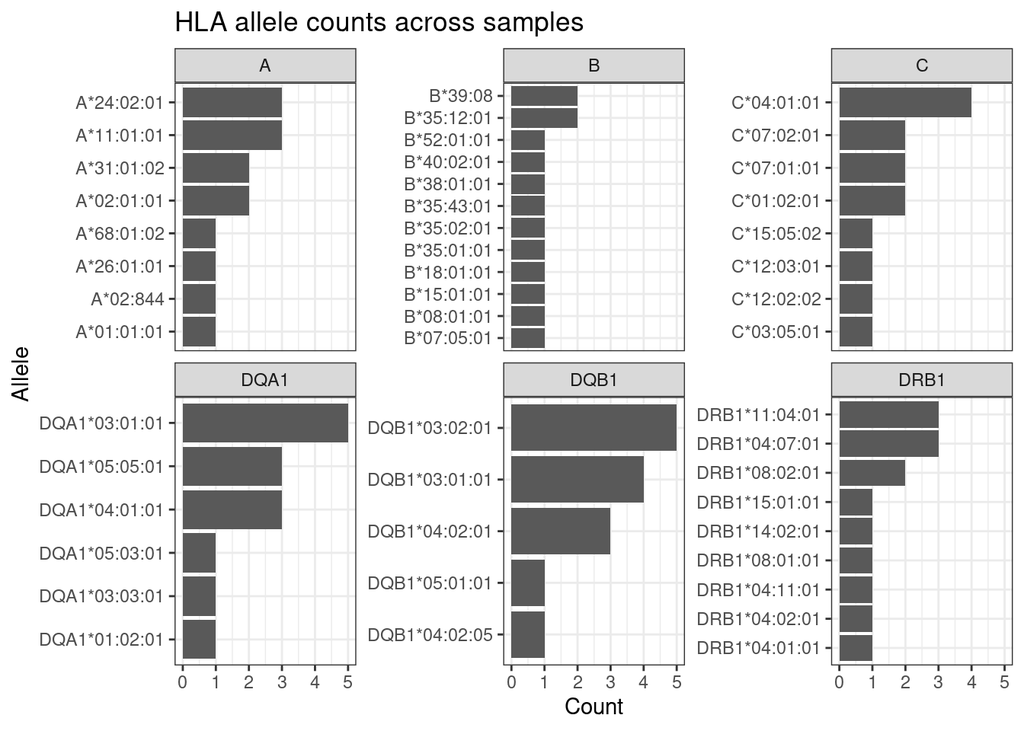

```r
p_counts <- ggplot(
  allele_counts,
  aes(x = reorder(Allele, n), y = n)
) +
  geom_col() +
  coord_flip() +
  facet_wrap(~ Gene, scales = "free_y") +
  theme_bw() +
  labs(
    title = "HLA allele counts across samples",
    x = "Allele",
    y = "Count"
  )

p_counts
```

```r
ggsave(
  file.path(out_dir, "arcasHLA_allele_counts.png"),
  p_counts,
  width = 12,
  height = 8,
  dpi = 300
)

ggsave(
  file.path(out_dir, "arcasHLA_allele_counts.pdf"),
  p_counts,
  width = 12,
  height = 8
)
```

# Two-field simplified HLA calls

For downstream TCR restriction matching, two-field resolution is often easier to use. For example, `A*02:01:01` becomes `A*02:01`.

```r
simplify_hla <- function(x) {
  ifelse(
    is.na(x),
    NA,
    str_extract(x, "^[A-Z0-9]+\\*\\d+:\\d+")
  )
}

hla_simple <- hla_df %>%
  mutate(
    Allele1_2field = simplify_hla(Allele1),
    Allele2_2field = simplify_hla(Allele2),
    Genotype_2field = paste(Allele1_2field, Allele2_2field, sep = " / ")
  )

hla_simple_wide <- hla_simple %>%
  select(Sample, Gene, Genotype_2field) %>%
  pivot_wider(
    names_from = Gene,
    values_from = Genotype_2field,
    names_prefix = "HLA_"
  ) %>%
  arrange(Sample)

write_csv(hla_simple_wide, file.path(out_dir, "arcasHLA_genotype_2field_wide.csv"))

hla_simple_wide %>%
  kable() %>%
  kable_styling(full_width = FALSE)
```

| Sample | HLA_A | HLA_B | HLA_C | HLA_DQA1 | HLA_DQB1 | HLA_DRB1 |
| --- | --- | --- | --- | --- | --- | --- |
| Manthiram_T101_S40 | A*24:02 / A*11:01 | B*07:05 / B*15:01 | C*15:05 / C*01:02 | DQA1*03:01 / DQA1*05:05 | DQB1*03:01 / DQB1*03:02 | DRB1*04:07 / DRB1*11:04 |
| Manthiram_T103_S41 | A*24:02 / A*68:01 | B*39:08 / B*35:12 | C*04:01 / C*07:02 | DQA1*04:01 / DQA1*04:01 | DQB1*04:02 / DQB1*04:02 | DRB1*08:02 / DRB1*08:02 |
| Manthiram_T10_S39 | A*01:01 / A*02:01 | B*08:01 / B*35:02 | C*04:01 / C*07:01 | DQA1*04:01 / DQA1*05:05 | DQB1*03:01 / DQB1*04:02 | DRB1*11:04 / DRB1*08:01 |
| Manthiram_T126_S42 | A*02:01 / A*11:01 | B*35:12 / B*52:01 | C*04:01 / C*12:02 | DQA1*03:01 / DQA1*01:02 | DQB1*03:02 / DQB1*05:01 | DRB1*04:07 / DRB1*15:01 |
| Manthiram_T133_S43 | A*26:01 / A*24:02 | B*38:01 / B*18:01 | C*07:01 / C*12:03 | DQA1*03:01 / DQA1*05:05 | DQB1*03:01 / DQB1*03:02 | DRB1*04:02 / DRB1*11:04 |
| Manthiram_T22_S44 | A*02:844 / A*31:01 | B*39:08 / B*35:43 | C*07:02 / C*01:02 | DQA1*05:03 / DQA1*03:03 | DQB1*04:02 / DQB1*03:01 | DRB1*04:11 / DRB1*14:02 |
| Manthiram_T70_S45 | A*31:01 / A*11:01 | B*40:02 / B*35:01 | C*04:01 / C*03:05 | DQA1*03:01 / DQA1*03:01 | DQB1*03:02 / DQB1*03:02 | DRB1*04:07 / DRB1*04:01 |

# T22 HLA-A call inspection

One sample, `Manthiram_T22_S44`, was called as:

```r
hla_wide %>%
  filter(Sample == "Manthiram_T22_S44") %>%
  select(Sample, HLA_A, HLA_B, HLA_C) %>%
  kable() %>%
  kable_styling(full_width = FALSE)
```

| Sample | HLA_A | HLA_B | HLA_C |
| --- | --- | --- | --- |
| Manthiram_T22_S44 | A*02:844 / A*31:01:02 | B*39:08 / B*35:43:01 | C*07:02:01 / C*01:02:01 |

The HLA-A call includes `A*02:844`, which is less common than alleles such as `A*02:01`. Review of the Arcas-HLA genotype log showed that the sample had strong HLA-A read support and that multiple closely related A*02 alleles had similar support. The most important biological interpretation for the SARS-CoV-2 TCR analysis is that this sample carries an HLA-A*02 family allele and an HLA-A*31 allele.

# Summary

The Arcas-HLA run successfully generated complete HLA calls for all samples across the requested loci. The Class I calls, especially HLA-A, HLA-B, and HLA-C, are the most important results for interpreting SARS-CoV-2-responsive CD8 TCRs. These HLA calls can be used to evaluate whether published TCR-HLA restrictions are compatible with each subject’s inferred HLA genotype.

Key output files generated by this report:

```r
list.files(out_dir, full.names = FALSE)
```

```
 [1] "arcasHLA_allele_counts.csv"
 [2] "arcasHLA_allele_counts.pdf"
 [3] "arcasHLA_allele_counts.png"
 [4] "arcasHLA_classI_for_CD8_TCR.csv"
 [5] "arcasHLA_genotype_2field_wide.csv"
 [6] "arcasHLA_genotype_heatmap.pdf"
 [7] "arcasHLA_genotype_heatmap.png"
 [8] "arcasHLA_genotype_long.csv"
 [9] "arcasHLA_genotype_table_for_report.csv"
[10] "arcasHLA_genotype_wide.csv"
```